# W241 Class Project - Analysis

# 1. Load libraries, data

Load up the data and do simple analysis. This version uses the complete dataset.

```r
# Libraries
library(lmtest)
library(sandwich)
library(ggplot2)
library(data.table)
library(stargazer)
library(ri)
library(multiwayvcov)
library(AER)
rm(list=ls())
d <- read.csv('~/Documents/mids-w241-final/Analysis/Combined Log.csv')
#d <- read.csv("C:/Users/Chris/OneDrive/Documents/MIDS/WS241/final/mids-w241-final/Analysis/Combined Log.csv")
d <- data.table(d)
# d <- d[complete.cases(d),] drops any row that is incomplete - too stringent since we have some cols which are not essential
d <- d[!is.na(no)] # Just drop row with missing values
# d <- d[complete.cases(d),] drops any row that is too incomplete - too stringent since we have some cols which are not essential
#d <- d[!is.na(no)] # Just drop row with missing values
# Base data
head(d)
```

| no | city | title | posting_date | bedrooms | sqft | price | posting_ID | treatment_assignment | full_URL | reply_email_TO_BE_FILLED_IN_standard | professional | duplicate_email | sent | outcome | received | notes |
| --- | --- | --- | --- | --- | --- | --- | --- | --- | --- | --- | --- | --- | --- | --- | --- | --- |
| 6 | seattle | Top Floor 2x2 Park & Lake Side/Corner Home!! USB Plugins!! | 3/17/2017 13:32 | 2 | 974 | 1791 | 6048316300 | Jane_Treat_High | https://seattle.craigslist.org/est/apa/6048316300.html | 2000lakewa@mailer.knockrentals.com | 1 | 0 | 3/18/2017 17:04 | 0 |  | Exclude - automatic reply |
| 87 | chicago | 836 S Bishop St #G | 3/17/2017 15:22 | 2 | NA | 2050 | 6048285644 | Jane_Treat_Low | https://chicago.craigslist.org/chc/apa/6048285644.html | 210758.lead@cendant.leadrouter.com | 0 | 0 | 0 | 0 | 0 |  |
| 62 | houston | Sophisticated Living 2 BR APT with Excellent Amenities-Receive Up To $ | 3/17/2017 15:24 | 2 | 1141 | 1598 | 6048284551 | Jane_Treat_High | https://houston.craigslist.org/apa/6048284551.html | 27hkh-6048284551@hous.craigslist.org | 1 | 0 |  | 0 |  |  |
| 89 | chicago | ALL BRAND NEW OUTSTANDING EAST LAKEVIEW LOCATION | 3/17/2017 15:27 | 1 | 1100 | 1995 | 6045134060 | Jane_Treat_Low | https://chicago.craigslist.org/chc/apa/6045134060.html | 2gndz-6045134060@hous.craigslist.org | 1 | 0 | 3/19/2017 19:28 | 1 | 3/21/2018 20:31 |  |
| 96 | chicago | Upgrade your lifestyle. Inexpensive with great character! | 3/17/2017 15:26 | 1 | NA | 1650 | 6038182650 | Jane_Control | https://chicago.craigslist.org/chc/apa/6038182650.html | 2gsp5-6038182650@hous.craigslist.org | 0 | 0 | 0 | 0 | 0 |  |
| 26 | seattle | LUXURY 2 BEDROOM ***2 Master Suites*Coming Soon! Call for Availability | 3/17/2017 13:11 | 2 | 1234 | 1655 | 6048285353 | John_Treat_Low | https://seattle.craigslist.org/tac/apa/6048285353.html | 2hnhn-6048285353@hous.craigslist.org | 1 | 0 | 3/18/2017 22:39 | 1 | 3/19/2017 16:17 |  |

```r
# Convert, transform data for analysis
# Drop some cols
d[,c('title','full_URL', 'reply_email_TO_BE_FILLED_IN_standard','posting_ID','notes') :=NULL]
# Set gender = 1 for Jane
d[treatment_assignment=='Jane_Control' | treatment_assignment=='Jane_Treat_High' | treatment_assignment=='Jane_Treat_Low',gender:=1]
d[treatment_assignment=='John_Control' | treatment_assignment=='John_Treat_High' | treatment_assignment=='John_Treat_Low',gender:=0]
# Set treatment variable = 0 for control, 1 for low, 2 for high (treatment here is continuous)
d[treatment_assignment=='Jane_Control' | treatment_assignment=='John_Control', treatment:=0]
d[treatment_assignment=='Jane_Treat_Low' | treatment_assignment=='John_Treat_Low', treatment:=1]
d[treatment_assignment=='Jane_Treat_High' | treatment_assignment=='John_Treat_High', treatment:=2]
# Alternatively, treat treatment types as categorical variables instead of continuous
d[treatment_assignment=='Jane_Treat_Low' | treatment_assignment=='John_Treat_Low', low_treatment:=1]
d[treatment_assignment=='Jane_Treat_High' | treatment_assignment=='John_Treat_High', high_treatment:=1]
d$low_treatment[is.na(d$low_treatment)] <- 0
d$high_treatment[is.na(d$high_treatment)] <- 0
d[low_treatment==1 | high_treatment==0, assigned:=1]
d$assigned[is.na(d$assigned)] <- 0
# Capture complier
#d[sent!='', compliers:=1]
#d$compliers[is.na(d$compliers)] <- 0
# Labeling data
d$gender <- factor(d$gender,labels = c("Male", "Female"))
d$outcome_f <- factor(d$outcome, labels = c("No Response", "Response"))
d$bedrooms <- factor(d$bedrooms, labels = c("1-bedroom", "2-bedroom"))
d$professional <- factor(d$professional, labels = c("Non-professional", "Professional"))
d$treatment_f <- factor(d$treatment, labels = c("Control","Low","High"))
head(d)
```

| no | city | posting_date | bedrooms | sqft | price | treatment_assignment | professional | duplicate_email | sent | outcome | received | gender | treatment | low_treatment | high_treatment | assigned | outcome_f | treatment_f |
| --- | --- | --- | --- | --- | --- | --- | --- | --- | --- | --- | --- | --- | --- | --- | --- | --- | --- | --- |
| 6 | seattle | 3/17/2017 13:32 | 2-bedroom | 974 | 1791 | Jane_Treat_High | Professional | 0 | 3/18/2017 17:04 | 0 |  | Female | 2 | 0 | 1 | 0 | No Response | High |
| 87 | chicago | 3/17/2017 15:22 | 2-bedroom | NA | 2050 | Jane_Treat_Low | Non-professional | 0 | 0 | 0 | 0 | Female | 1 | 1 | 0 | 1 | No Response | Low |
| 62 | houston | 3/17/2017 15:24 | 2-bedroom | 1141 | 1598 | Jane_Treat_High | Professional | 0 |  | 0 |  | Female | 2 | 0 | 1 | 0 | No Response | High |
| 89 | chicago | 3/17/2017 15:27 | 1-bedroom | 1100 | 1995 | Jane_Treat_Low | Professional | 0 | 3/19/2017 19:28 | 1 | 3/21/2018 20:31 | Female | 1 | 1 | 0 | 1 | Response | Low |
| 96 | chicago | 3/17/2017 15:26 | 1-bedroom | NA | 1650 | Jane_Control | Non-professional | 0 | 0 | 0 | 0 | Female | 0 | 0 | 0 | 1 | No Response | Control |
| 26 | seattle | 3/17/2017 13:11 | 2-bedroom | 1234 | 1655 | John_Treat_Low | Professional | 0 | 3/18/2017 22:39 | 1 | 3/19/2017 16:17 | Male | 1 | 1 | 0 | 1 | Response | Low |

```r
NA
```

# 2. Check data, do simple tables to check for balance

Recode missing sqft values. It’s not necessary but we use this in some of our model specifications.

```r
# Recode missing sqft with mean of cluster (city)
d[, Mean:=mean(sqft, na.rm=TRUE), by=city]
d[is.na(sqft)]$sqft <- d[is.na(sqft)]$Mean
```

```
Coerced 'double' RHS to 'integer' to match the column's type; may have truncated precision. Either change the target column to 'double' first (by creating a new 'double' vector length 483 (nrows of entire table) and assign that; i.e. 'replace' column), or coerce RHS to 'integer' (e.g. 1L, NA_[real|i…
```

```r
d[,c('Mean') :=NULL]
```

Remove duplicate emails

```r
# If duplicate, only retain first email sent, sets up for exploration later; in our base exploration we did not exclude duplicate emails
#d <- d[duplicate_email == 0]
```

For the most part it looks like we have a balanced dataset.

```r
cat('Table of Outcomes:')
```

```
Table of Outcomes:
```

```r
table(d$outcome_f)
```

```
No Response    Response
        264         219
```

```r
cat('\nTable of Outcomes (By Gender):')
```

```
Table of Outcomes (By Gender):
```

```r
table(d$outcome_f, d$gender)
```

```
              Male Female
  No Response  135    129
  Response     104    115
```

```r
cat('\nTable of Outcomes (By Treatment):')
```

```
Table of Outcomes (By Treatment):
```

```r
table(d$outcome_f, d$treatment_f)
```

```
              Control Low High
  No Response      88  89   87
  Response         72  72   75
```

```r
cat('\nTable of Outcomes (By Treatment and Gender):')
```

```
Table of Outcomes (By Treatment and Gender):
```

```r
table(d$outcome_f, factor(d$treatment_assignment))
```

```
              Jane_Control Jane_Treat_High Jane_Treat_Low John_Control John_Treat_High John_Treat_Low
  No Response           39              41             49           49              46             40
  Response              39              40             36           33              35             36
```

```r
cat('\nTable of Outcomes (By City):')
```

```
Table of Outcomes (By City):
```

```r
table(d$outcome_f,factor(d$city))
```

```
              chicago houston sandiego seattle
  No Response      63      79       65      57
  Response         61      40       52      66
```

```r
cat('\nTable of Outcomes (By Rooms):')
```

```
Table of Outcomes (By Rooms):
```

```r
table(d$outcome_f,factor(d$bedrooms))
```

```
              1-bedroom 2-bedroom
  No Response       130       134
  Response          103       116
```

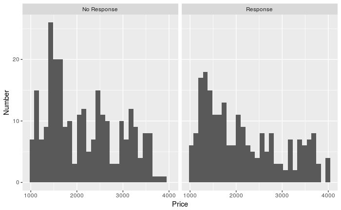

```r
ggplot(d,aes(x=price))+geom_histogram()+facet_grid(~outcome_f)+labs(x="Price",y="Number")
```

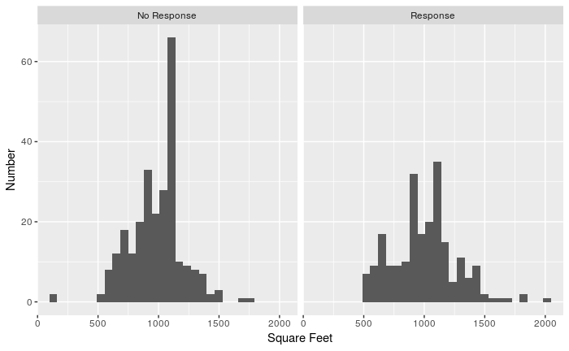

```r
# Sqft info has missing values => we can drop all cases (see above) but for now leave this alone or we use the clustering estimate
# Similar but somewhat worse issue for professional, same.email info
ggplot(d,aes(x=sqft))+geom_histogram()+facet_grid(~outcome_f)+labs(x="Square Feet",y="Number")
```

```r
cat('\nTable of Outcomes (By Professional):')
```

```
Table of Outcomes (By Professional):
```

```r
table(d$outcome_f,factor(d$professional))
```

```
              Non-professional Professional
  No Response               55          209
  Response                  35          184
```

# 3. Analysis

# Simple Analysis

We do a chi-squared test of independence to see if the observations are independent. We cannot reject the hypothesis that the observations are indpendent. This is true for even the professional category.

```r
# For Outcome and Gender
tbl <- table(d$outcome_f,d$gender)
tbl
```

```
              Male Female
  No Response  135    129
  Response     104    115
```

```r
chisq.test(tbl)
```

```
    Pearson's Chi-squared test with Yates' continuity correction

data:  tbl
X-squared = 0.49961, df = 1, p-value = 0.4797
```

```r
# On Outcome and Treatment
tbl <- table(d$outcome_f,d$treatment)
tbl
```

```
               0  1  2
  No Response 88 89 87
  Response    72 72 75
```

```r
chisq.test(tbl)
```

```
    Pearson's Chi-squared test

data:  tbl
X-squared = 0.092173, df = 2, p-value = 0.955
```

```r
# On Outcome and Treatment Assignment
tbl <- table(d$outcome_f,factor(d$treatment_assignment))
tbl
```

```
              Jane_Control Jane_Treat_High Jane_Treat_Low John_Control John_Treat_High John_Treat_Low
  No Response           39              41             49           49              46             40
  Response              39              40             36           33              35             36
```

```r
chisq.test(tbl)
```

```
    Pearson's Chi-squared test

data:  tbl
X-squared = 2.6574, df = 5, p-value = 0.7526
```

```r
# On Outcome and Professional
tbl <- table(d$outcome_f,d$professional)
tbl
```

```
              Non-professional Professional
  No Response               55          209
  Response                  35          184
```

```r
chisq.test(tbl)
```

```
    Pearson's Chi-squared test with Yates' continuity correction

data:  tbl
X-squared = 1.5521, df = 1, p-value = 0.2128
```

# Regression

We run regression on treatment as a factor (control, low, high) with and without gender as another factor. Other co-variates are added including city, price, bedrooms.

Basic model

```
Outcome variable = alpha + B_high + B_low + gender + covariates
```

```r
# First we treat treatment as a continous variable
# Model 1a - Basic model
m1 <- lm(outcome~treatment,data=d)
stargazer(m1,type='text')
```

```
===============================================
                        Dependent variable:
                    ---------------------------
                              outcome
-----------------------------------------------
treatment                      0.005
                              (0.048)

Constant                     0.450***
                              (0.039)

-----------------------------------------------
Observations                    483
R2                            0.00002
Adjusted R2                   -0.002
Residual Std. Error      0.499 (df = 481)
F Statistic             0.011 (df = 1; 481)
===============================================
Note:               *p<0.1; **p<0.05; ***p<0.01
```

```r
coeftest(m1, vcovHC(m1)) # Robust se
```

```
t test of coefficients:

             Estimate Std. Error t value Pr(>|t|)
(Intercept) 0.4500000  0.0395777 11.3700   <2e-16 ***
treatment   0.0051084  0.0483624  0.1056   0.9159
---
Signif. codes:  0 ‘***’ 0.001 ‘**’ 0.01 ‘*’ 0.05 ‘.’ 0.1 ‘ ’ 1
```

```r
# Model 2a - Treatment & gender
m2 <- lm(outcome~treatment*gender,data=d)
stargazer(m2,type='text')
```

```
==================================================
                           Dependent variable:
                       ---------------------------
                                 outcome
--------------------------------------------------
treatment                         0.050
                                 (0.068)

genderFemale                      0.098
                                 (0.079)

treatment:genderFemale           -0.092
                                 (0.097)

Constant                        0.402***
                                 (0.055)

--------------------------------------------------
Observations                       483
R2                                0.003
Adjusted R2                      -0.003
Residual Std. Error         0.499 (df = 479)
F Statistic                0.516 (df = 3; 479)
==================================================
Note:                  *p<0.1; **p<0.05; ***p<0.01
```

```r
coeftest(m2, vcovHC(m2)) # Robust se
```

```
t test of coefficients:

                        Estimate Std. Error t value  Pr(>|t|)
(Intercept)             0.402439   0.054823  7.3407 9.182e-13 ***
treatment               0.049790   0.067850  0.7338    0.4634
genderFemale            0.097561   0.079338  1.2297    0.2194
treatment:genderFemale -0.091959   0.096985 -0.9482    0.3435
---
Signif. codes:  0 ‘***’ 0.001 ‘**’ 0.01 ‘*’ 0.05 ‘.’ 0.1 ‘ ’ 1
```

```r
# Model 3a - Treatment & gender + covariates
m3 <- lm(outcome~treatment*gender+factor(city)+factor(bedrooms)+price,data=d)
stargazer(m3,type='text')
```

```
=====================================================
                              Dependent variable:
                          ---------------------------
                                    outcome
-----------------------------------------------------
treatment                            0.051
                                    (0.068)

genderFemale                         0.097
                                    (0.079)

factor(city)houston                -0.155**
                                    (0.064)

factor(city)sandiego                -0.045
                                    (0.064)

factor(city)seattle                  0.047
                                    (0.064)

factor(bedrooms)2-bedroom            0.031
                                    (0.049)

price                              -0.00000
                                   (0.00003)

treatment:genderFemale              -0.093
                                    (0.096)

Constant                           0.432***
                                    (0.090)

-----------------------------------------------------
Observations                          483
R2                                   0.026
Adjusted R2                          0.010
Residual Std. Error            0.496 (df = 474)
F Statistic                   1.605 (df = 8; 474)
=====================================================
Note:                     *p<0.1; **p<0.05; ***p<0.01
```

```r
coeftest(m3, vcovHC(m3)) # Robust se
```

```
t test of coefficients:

                             Estimate  Std. Error t value Pr(>|t|)
(Intercept)                4.3187e-01  9.2994e-02  4.6441 4.43e-06 ***
treatment                  5.1256e-02  6.7703e-02  0.7571  0.44938
genderFemale               9.6820e-02  7.9159e-02  1.2231  0.22190
factor(city)houston       -1.5538e-01  6.3663e-02 -2.4406  0.01503 *
factor(city)sandiego      -4.5435e-02  6.5768e-02 -0.6908  0.49001
factor(city)seattle        4.6560e-02  6.4985e-02  0.7165  0.47406
factor(bedrooms)2-bedroom  3.1126e-02  4.8262e-02  0.6449  0.51928
price                     -3.8356e-06  3.0690e-05 -0.1250  0.90059
treatment:genderFemale    -9.3189e-02  9.6840e-02 -0.9623  0.33639
---
Signif. codes:  0 ‘***’ 0.001 ‘**’ 0.01 ‘*’ 0.05 ‘.’ 0.1 ‘ ’ 1
```

```r
# Model 3a-1 - Treatment & gender + all covariates including less reliable sqft and professoinal
m3.1 <- lm(outcome~treatment*gender+factor(city)+factor(bedrooms)+price+sqft+professional,data=d)
stargazer(m3.1,type='text')
```

```
=====================================================
                              Dependent variable:
                          ---------------------------
                                    outcome
-----------------------------------------------------
treatment                            0.045
                                    (0.068)

genderFemale                         0.103
                                    (0.078)

factor(city)houston                -0.175***
                                    (0.066)

factor(city)sandiego                -0.029
                                    (0.068)

factor(city)seattle                  0.051
                                    (0.069)

factor(bedrooms)2-bedroom           -0.0004
                                    (0.054)

price                              -0.00003
                                   (0.00003)

sqft                                0.0002
                                   (0.0001)

professionalProfessional            0.125**
                                    (0.062)

treatment:genderFemale              -0.092
                                    (0.096)

Constant                             0.205
                                    (0.144)

-----------------------------------------------------
Observations                          483
R2                                   0.038
Adjusted R2                          0.018
Residual Std. Error            0.494 (df = 472)
F Statistic                 1.864** (df = 10; 472)
=====================================================
Note:                     *p<0.1; **p<0.05; ***p<0.01
```

```r
coeftest(m3.1, vcovHC(m3.1)) # Robust se
```

```
t test of coefficients:

                             Estimate  Std. Error t value Pr(>|t|)
(Intercept)                2.0546e-01  1.4527e-01  1.4143 0.157936
treatment                  4.4953e-02  6.8155e-02  0.6596 0.509857
genderFemale               1.0259e-01  7.9008e-02  1.2985 0.194752
factor(city)houston       -1.7456e-01  6.6128e-02 -2.6397 0.008572 **
factor(city)sandiego      -2.9036e-02  6.9619e-02 -0.4171 0.676819
factor(city)seattle        5.0883e-02  7.0620e-02  0.7205 0.471566
factor(bedrooms)2-bedroom -4.2180e-04  5.2647e-02 -0.0080 0.993611
price                     -3.0302e-05  3.3411e-05 -0.9069 0.364902
sqft                       1.9973e-04  1.2202e-04  1.6368 0.102329
professionalProfessional   1.2542e-01  6.3676e-02  1.9696 0.049465 *
treatment:genderFemale    -9.1867e-02  9.6821e-02 -0.9488 0.343192
---
Signif. codes:  0 ‘***’ 0.001 ‘**’ 0.01 ‘*’ 0.05 ‘.’ 0.1 ‘ ’ 1
```

```r
# Next we treat treatment as a categorical variable (effect might not be linear)
# Model 1b - Basic model
m4 <- lm(outcome~treatment_f,data=d)
stargazer(m4,type='text')
```

```
===============================================
                        Dependent variable:
                    ---------------------------
                              outcome
-----------------------------------------------
treatment_fLow                -0.003
                              (0.056)

treatment_fHigh                0.013
                              (0.056)

Constant                     0.450***
                              (0.039)

-----------------------------------------------
Observations                    483
R2                            0.0002
Adjusted R2                   -0.004
Residual Std. Error      0.499 (df = 480)
F Statistic             0.046 (df = 2; 480)
===============================================
Note:               *p<0.1; **p<0.05; ***p<0.01
```

```r
coeftest(m4, vcovHC(m4)) # Robust se
```

```
t test of coefficients:

                 Estimate Std. Error t value Pr(>|t|)
(Intercept)      0.450000   0.039578 11.3700   <2e-16 ***
treatment_fLow  -0.002795   0.055867 -0.0500   0.9601
treatment_fHigh  0.012963   0.055859  0.2321   0.8166
---
Signif. codes:  0 ‘***’ 0.001 ‘**’ 0.01 ‘*’ 0.05 ‘.’ 0.1 ‘ ’ 1
```

```r
# Model 2b - Treatment & gender
m5 <- lm(outcome~treatment_f*gender,data=d)
stargazer(m5,type='text')
```

```
========================================================
                                 Dependent variable:
                             ---------------------------
                                       outcome
--------------------------------------------------------
treatment_fLow                          0.071
                                       (0.080)

treatment_fHigh                         0.030
                                       (0.078)

genderFemale                            0.098
                                       (0.079)

treatment_fLow:genderFemale            -0.148
                                       (0.112)

treatment_fHigh:genderFemale           -0.036
                                       (0.111)

Constant                              0.402***
                                       (0.055)

--------------------------------------------------------
Observations                             483
R2                                      0.006
Adjusted R2                            -0.005
Residual Std. Error               0.500 (df = 477)
F Statistic                      0.528 (df = 5; 477)
========================================================
Note:                        *p<0.1; **p<0.05; ***p<0.01
```

```r
coeftest(m5, vcovHC(m5)) # Robust se
```

```
t test of coefficients:

                              Estimate Std. Error t value  Pr(>|t|)
(Intercept)                   0.402439   0.054823  7.3407 9.234e-13 ***
treatment_fLow                0.071245   0.079837  0.8924    0.3726
treatment_fHigh               0.029660   0.078175  0.3794    0.7046
genderFemale                  0.097561   0.079338  1.2297    0.2194
treatment_fLow:genderFemale  -0.147716   0.112268 -1.3157    0.1889
treatment_fHigh:genderFemale -0.035833   0.112088 -0.3197    0.7493
---
Signif. codes:  0 ‘***’ 0.001 ‘**’ 0.01 ‘*’ 0.05 ‘.’ 0.1 ‘ ’ 1
```

```r
# Model 3b - Treatment & gender + covariates
m6 <- lm(outcome~treatment_f*gender+factor(city)+factor(bedrooms)+price,data=d)
stargazer(m6,type='text')
```

```
========================================================
                                 Dependent variable:
                             ---------------------------
                                       outcome
--------------------------------------------------------
treatment_fLow                          0.074
                                       (0.079)

treatment_fHigh                         0.031
                                       (0.078)

genderFemale                            0.097
                                       (0.079)

factor(city)houston                   -0.157**
                                       (0.064)

factor(city)sandiego                   -0.047
                                       (0.064)

factor(city)seattle                     0.044
                                       (0.064)

factor(bedrooms)2-bedroom               0.032
                                       (0.049)

price                                 -0.00000
                                      (0.00003)

treatment_fLow:genderFemale            -0.151
                                       (0.111)

treatment_fHigh:genderFemale           -0.035
                                       (0.111)

Constant                              0.433***
                                       (0.091)

--------------------------------------------------------
Observations                             483
R2                                      0.029
Adjusted R2                             0.008
Residual Std. Error               0.496 (df = 472)
F Statistic                     1.399 (df = 10; 472)
========================================================
Note:                        *p<0.1; **p<0.05; ***p<0.01
```

```r
coeftest(m6, vcovHC(m6)) # Robust se
```

```
t test of coefficients:

                                Estimate  Std. Error t value  Pr(>|t|)
(Intercept)                   4.3327e-01  9.3187e-02  4.6495 4.325e-06 ***
treatment_fLow                7.3544e-02  7.9784e-02  0.9218    0.3571
treatment_fHigh               3.0518e-02  7.8207e-02  0.3902    0.6966
genderFemale                  9.6823e-02  7.9161e-02  1.2231    0.2219
factor(city)houston          -1.5723e-01  6.3812e-02 -2.4639    0.0141 *
factor(city)sandiego         -4.6826e-02  6.5934e-02 -0.7102    0.4779
factor(city)seattle           4.4475e-02  6.5228e-02  0.6818    0.4957
factor(bedrooms)2-bedroom     3.2102e-02  4.8609e-02  0.6604    0.5093
price                        -4.1162e-06  3.0934e-05 -0.1331    0.8942
treatment_fLow:genderFemale  -1.5084e-01  1.1212e-01 -1.3453    0.1792
treatment_fHigh:genderFemale -3.5359e-02  1.1210e-01 -0.3154    0.7526
---
Signif. codes:  0 ‘***’ 0.001 ‘**’ 0.01 ‘*’ 0.05 ‘.’ 0.1 ‘ ’ 1
```

```r
# Model 3b-1 - Treatment & gender + all covariates including less reliable sqft and professoinal
m6.1 <- lm(outcome~treatment_f*gender+factor(city)+factor(bedrooms)+price+sqft+professional,data=d)
stargazer(m6.1,type='text')
```

```
========================================================
                                 Dependent variable:
                             ---------------------------
                                       outcome
--------------------------------------------------------
treatment_fLow                          0.063
                                       (0.079)

treatment_fHigh                         0.028
                                       (0.078)

genderFemale                            0.102
                                       (0.078)

factor(city)houston                   -0.177***
                                       (0.066)

factor(city)sandiego                   -0.032
                                       (0.068)

factor(city)seattle                     0.047
                                       (0.069)

factor(bedrooms)2-bedroom               0.002
                                       (0.054)

price                                 -0.00003
                                      (0.00003)

sqft                                   0.0002
                                      (0.0001)

professionalProfessional               0.128**
                                       (0.063)

treatment_fLow:genderFemale            -0.147
                                       (0.111)

treatment_fHigh:genderFemale           -0.035
                                       (0.111)

Constant                                0.212
                                       (0.144)

--------------------------------------------------------
Observations                             483
R2                                      0.040
Adjusted R2                             0.016
Residual Std. Error               0.494 (df = 470)
F Statistic                     1.649* (df = 12; 470)
========================================================
Note:                        *p<0.1; **p<0.05; ***p<0.01
```

```r
coeftest(m6.1, vcovHC(m6.1)) # Robust se
```

```
t test of coefficients:

                                Estimate  Std. Error t value Pr(>|t|)
(Intercept)                   2.1190e-01  1.4458e-01  1.4656 0.143427
treatment_fLow                6.2881e-02  8.0392e-02  0.7822 0.434503
treatment_fHigh               2.7746e-02  7.8568e-02  0.3531 0.724137
genderFemale                  1.0238e-01  7.9039e-02  1.2953 0.195852
factor(city)houston          -1.7745e-01  6.6167e-02 -2.6819 0.007579 **
factor(city)sandiego         -3.2071e-02  6.9557e-02 -0.4611 0.644961
factor(city)seattle           4.6910e-02  7.0773e-02  0.6628 0.507773
factor(bedrooms)2-bedroom     2.2089e-03  5.2914e-02  0.0417 0.966719
price                        -3.0535e-05  3.3802e-05 -0.9033 0.366804
sqft                          1.9285e-04  1.2171e-04  1.5845 0.113755
professionalProfessional      1.2789e-01  6.3882e-02  2.0020 0.045859 *
treatment_fLow:genderFemale  -1.4664e-01  1.1200e-01 -1.3093 0.191081
treatment_fHigh:genderFemale -3.5093e-02  1.1223e-01 -0.3127 0.754666
---
Signif. codes:  0 ‘***’ 0.001 ‘**’ 0.01 ‘*’ 0.05 ‘.’ 0.1 ‘ ’ 1
```

In all models, the coefficients on treatment, whether continous or as a factor, are not statistically significant. If we add gender, there is also no evidence of a the interaction term being statistically significant. Thus, there is no evidence that exclamation points have influenced the likelihood of receiving a response.

```r
# We try an alternative specification for treatment (as dummy variables)
# Model 1c - Basic model
m7 <- lm(outcome ~ low_treatment + high_treatment, data=d)
stargazer(m7, type='text')
```

```
===============================================
                        Dependent variable:
                    ---------------------------
                              outcome
-----------------------------------------------
low_treatment                 -0.003
                              (0.056)

high_treatment                 0.013
                              (0.056)

Constant                     0.450***
                              (0.039)

-----------------------------------------------
Observations                    483
R2                            0.0002
Adjusted R2                   -0.004
Residual Std. Error      0.499 (df = 480)
F Statistic             0.046 (df = 2; 480)
===============================================
Note:               *p<0.1; **p<0.05; ***p<0.01
```

```r
coeftest(m7, vcovHC(m7)) # Robust se
```

```
t test of coefficients:

                Estimate Std. Error t value Pr(>|t|)
(Intercept)     0.450000   0.039578 11.3700   <2e-16 ***
low_treatment  -0.002795   0.055867 -0.0500   0.9601
high_treatment  0.012963   0.055859  0.2321   0.8166
---
Signif. codes:  0 ‘***’ 0.001 ‘**’ 0.01 ‘*’ 0.05 ‘.’ 0.1 ‘ ’ 1
```

```r
# Model 2c - Treatment & gender
m8 <- lm(outcome ~ low_treatment + high_treatment*gender, data=d)
stargazer(m8, type='text')
```

```
=======================================================
                                Dependent variable:
                            ---------------------------
                                      outcome
-------------------------------------------------------
low_treatment                         -0.004
                                      (0.056)

high_treatment                        -0.006
                                      (0.073)

genderFemale                           0.024
                                      (0.056)

high_treatment:genderFemale            0.038
                                      (0.096)

Constant                             0.439***
                                      (0.048)

-------------------------------------------------------
Observations                            483
R2                                     0.002
Adjusted R2                           -0.007
Residual Std. Error              0.500 (df = 478)
F Statistic                     0.222 (df = 4; 478)
=======================================================
Note:                       *p<0.1; **p<0.05; ***p<0.01
```

```r
coeftest(m8, vcovHC(m8)) # Robust se
```

```
t test of coefficients:

                              Estimate Std. Error t value Pr(>|t|)
(Intercept)                  0.4385118  0.0478301  9.1681   <2e-16 ***
low_treatment               -0.0037483  0.0561084 -0.0668   0.9468
high_treatment              -0.0064131  0.0734399 -0.0873   0.9305
genderFemale                 0.0235655  0.0561118  0.4200   0.6747
high_treatment:genderFemale  0.0381629  0.0970455  0.3932   0.6943
---
Signif. codes:  0 ‘***’ 0.001 ‘**’ 0.01 ‘*’ 0.05 ‘.’ 0.1 ‘ ’ 1
```

```r
# Model 3c - Treatment & gender + covariates
m9 <- lm(outcome ~ low_treatment + high_treatment + gender + factor(city) + factor(bedrooms) + price, data=d)
stargazer(m9, type='text')
```

```
=====================================================
                              Dependent variable:
                          ---------------------------
                                    outcome
-----------------------------------------------------
low_treatment                       -0.004
                                    (0.056)

high_treatment                       0.014
                                    (0.055)

genderFemale                         0.035
                                    (0.045)

factor(city)houston                -0.154**
                                    (0.064)

factor(city)sandiego                -0.046
                                    (0.064)

factor(city)seattle                  0.048
                                    (0.064)

factor(bedrooms)2-bedroom            0.031
                                    (0.049)

price                              -0.00001
                                   (0.00003)

Constant                           0.466***
                                    (0.084)

-----------------------------------------------------
Observations                          483
R2                                   0.025
Adjusted R2                          0.008
Residual Std. Error            0.496 (df = 474)
F Statistic                   1.497 (df = 8; 474)
=====================================================
Note:                     *p<0.1; **p<0.05; ***p<0.01
```

```r
coeftest(m9, vcovHC(m9)) # Robust se
```

```
t test of coefficients:

                             Estimate  Std. Error t value  Pr(>|t|)
(Intercept)                4.6571e-01  8.6773e-02  5.3669 1.256e-07 ***
low_treatment             -3.7784e-03  5.5953e-02 -0.0675   0.94619
high_treatment             1.3738e-02  5.5896e-02  0.2458   0.80596
genderFemale               3.4752e-02  4.5695e-02  0.7605   0.44732
factor(city)houston       -1.5429e-01  6.3676e-02 -2.4230   0.01577 *
factor(city)sandiego      -4.5755e-02  6.5682e-02 -0.6966   0.48638
factor(city)seattle        4.7974e-02  6.4963e-02  0.7385   0.46059
factor(bedrooms)2-bedroom  3.0814e-02  4.8250e-02  0.6386   0.52337
price                     -5.6698e-06  3.0873e-05 -0.1836   0.85437
---
Signif. codes:  0 ‘***’ 0.001 ‘**’ 0.01 ‘*’ 0.05 ‘.’ 0.1 ‘ ’ 1
```

The coefficients on treatment are also statistically insignificant. There is no evidence that exclamation points have an effect.

## Randomization Inference

Next we use randomization inference (assuming a Sharp Null of No Effect) to understand if our observation is consistent with an empirical null distribution. For this, we combine low and high treatment into treatment (since we have not learned more complex fixes for heterogenous effects).

```r
# Combining treatments
di <- d
di[treatment==2,treatment:=1]
# Define distributions
y <- di$outcome
Z <- di$treatment
blk1 <- as.numeric(di$gender) # We block by gender
blk2 <- as.numeric(di$city) # Block by city
blk3 <- as.numeric(di$bedrooms)
# By gender
perms <- genperms(Z, clustvar = NULL, blockvar = blk1)
```

```
Too many permutations to use exact method.
Defaulting to approximate method.
Increase maxiter to at least 4.19386819554668e+130 to perform exact estimation.
```

```
$two.tailed.p.value
[1] 0.9748

$two.tailed.p.value.abs
[1] 0.9874

$greater.p.value
[1] 0.4874

$lesser.p.value
[1] 0.5192

$quantile
       2.5%       97.5%
-0.09838053  0.09753228

$sd
[1] 0.0484482

$exp.val
[1] -0.0004189318
```

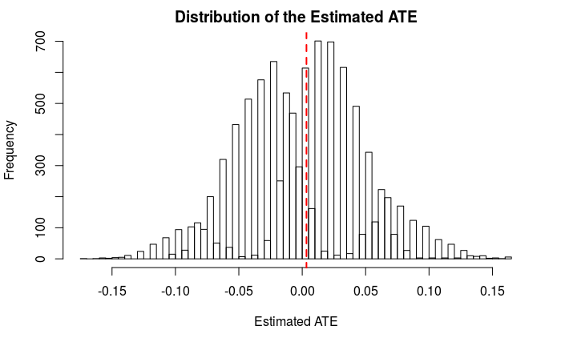

```r
probs <- genprobexact(Z, clustvar = NULL, blockvar = blk1) # probability of treatment
ate <- estate(y,Z,prob=probs) # estimate the ATE
Ys <- genouts(y,Z,ate=0) # generate potential outcomes under sharp null of no effect
distout <- gendist(Ys,perms, prob=probs) # generate sampling dist. under sharp null
dispdist(distout, ate, quantiles = c(0.025, 0.975), display.plot = TRUE) # display characteristics of sampling dist. for inference
```

```r
# By city
perms <- genperms(Z, clustvar = NULL, blockvar = blk2)
```

```
Too many permutations to use exact method.
Defaulting to approximate method.
Increase maxiter to at least 4.59676200506436e+128 to perform exact estimation.
```

```
$two.tailed.p.value
[1] 0.9064

$two.tailed.p.value.abs
[1] 0.893

$greater.p.value
[1] 0.4532

$lesser.p.value
[1] 0.5475

$quantile
       2.5%       97.5%
-0.09654754  0.09120148

$sd
[1] 0.04817207

$exp.val
[1] -0.0006351514
```

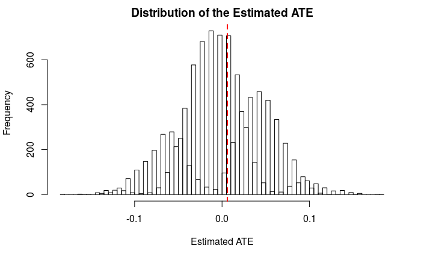

```r
probs <- genprobexact(Z, clustvar = NULL, blockvar = blk2) # probability of treatment
ate <- estate(y,Z,prob=probs) # estimate the ATE
Ys <- genouts(y,Z,ate=0) # generate potential outcomes under sharp null of no effect
distout <- gendist(Ys,perms, prob=probs) # generate sampling dist. under sharp null
dispdist(distout, ate, quantiles = c(0.025, 0.975), display.plot = TRUE) # display characteristics of sampling dist. for inference
```

```r
# By bedroom
perms <- genperms(Z, clustvar = NULL, blockvar = blk3)
```

```
Too many permutations to use exact method.
Defaulting to approximate method.
Increase maxiter to at least 4.80931839467142e+130 to perform exact estimation.
```

```
$two.tailed.p.value
[1] 0.9632

$two.tailed.p.value.abs
[1] 0.9082

$greater.p.value
[1] 0.4816

$lesser.p.value
[1] 0.528

$quantile
       2.5%       97.5%
-0.09763483  0.09827367

$sd
[1] 0.04858612

$exp.val
[1] 0.0003082015
```

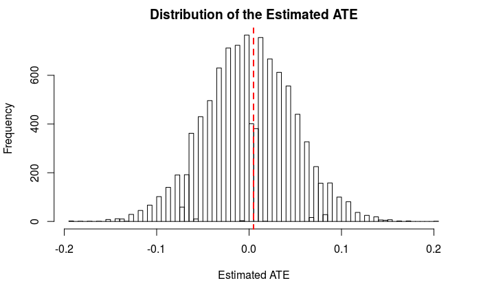

```r
probs <- genprobexact(Z, clustvar = NULL, blockvar = blk3) # probability of treatment
ate <- estate(y,Z,prob=probs) # estimate the ATE
Ys <- genouts(y,Z,ate=0) # generate potential outcomes under sharp null of no effect
distout <- gendist(Ys,perms, prob=probs) # generate sampling dist. under sharp null
dispdist(distout, ate, quantiles = c(0.025, 0.975), display.plot = TRUE) # display characteristics of sampling dist. for inference
```

```r
#P-value for actual data
p.val.actual = sum(abs(distout) > ate) / length(distout)
p.val.actual
```

```
[1] 0.8986
```

```r
#get respnse rate by treatment or control
actual.response.rate.by.treatment <- di[, mean(outcome), by = c("treatment")]
actual.response.rate.by.treatment
```

| treatment | V1 |
| --- | --- |
| 1 | 0.4551084 |
| 0 | 0.4500000 |

```r
di[, sum(outcome > -100), by = c("treatment")]
```

| treatment | V1 |
| --- | --- |
| 1 | 323 |
| 0 | 160 |

Once again, we cannot reject the null hypothesis of no effect.

## Other Analysis

1. Although not a signficant issue for this experiement we estimate the CACE. For this we define non-compliers as those for who we sent emails but did not received them - and we know this because we received a “bounced” email message.

```r
# We calculate the CACE manually
# Manually compute CACE
itt <- mean(d$outcome[d$treatment != 0]) - mean(d$outcome[d$treatment == 0])
prop_treated <- 481/483
sprintf("\nThe estimated CACE is: %.5f", itt / prop_treated)
```

```
[1] "\nThe estimated CACE is: 0.00513"
```

```r
# or 2SLS
#itt_fit <- ivreg(outcome ~treatment,~compliers,data=d)
#stargazer(itt_fit, type='text')
```

```r
# First, we use RI. create a new temp column of outcomes where the share of responses is n%
#To see what treatment response rate is required for significant result, adjust this variable.
#Found that a treatment response rate of about 0.6 would be required to observe significant result
treatment.response.rate <- 0.6
di$hypothetical.outcomes.temp <- sample(c(0,1), size = nrow(d), replace = TRUE, prob = c(1-treatment.response.rate, treatment.response.rate))
#create new outcome column that takes original outcomes for control group, but new hypothetical outcomes with adjusted response rate for treatment rows
di$hypothetical.outcomes = d$outcome
di[treatment==1, hypothetical.outcomes:=hypothetical.outcomes.temp]
```

```
Coerced 'double' RHS to 'integer' to match the column's type; may have truncated precision. Either change the target column to 'double' first (by creating a new 'double' vector length 483 (nrows of entire table) and assign that; i.e. 'replace' column), or coerce RHS to 'integer' (e.g. 1L, NA_[real|i…
```

```r
fake.response.rate.by.treatment <- di[, mean(hypothetical.outcomes), by = c("treatment")]
fake.response.rate.by.treatment
```

| treatment | V1 |
| --- | --- |
| 1 | 0.6037152 |
| 0 | 0.4500000 |

```r
#run RI using the fake data
y.fake <- di$hypothetical.outcomes
Z.fake <- di$treatment
cls.fake <- di$gender
blk.fake <- di$city
perms.fake <- genperms(Z.fake, clustvar = NULL, blockvar = blk.fake)
```

```
Too many permutations to use exact method.
Defaulting to approximate method.
Increase maxiter to at least 4.59676200506436e+128 to perform exact estimation.
```

```
$two.tailed.p.value
[1] 0.0014

$two.tailed.p.value.abs
[1] 0.0013

$greater.p.value
[1] 7e-04

$lesser.p.value
[1] 0.9993

$quantile
       2.5%       97.5%
-0.09569790  0.09060323

$sd
[1] 0.04780999

$exp.val
[1] -0.0001980287
```

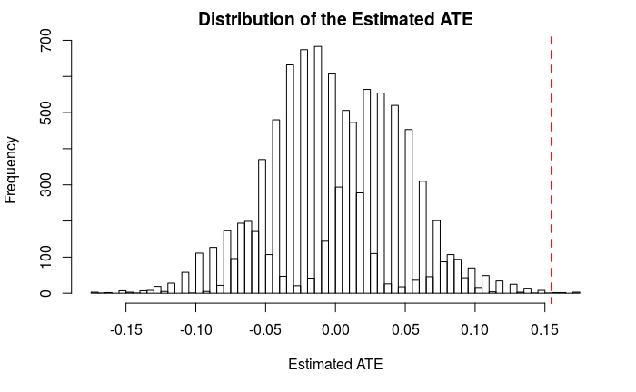

```r
probs.fake <- genprobexact(Z.fake, clustvar = NULL, blockvar = blk.fake) # probability of treatment
ate.fake <- estate(y.fake,Z.fake,prob=probs.fake) # estimate the ATE
Ys.fake <- genouts(y.fake,Z.fake,ate=0) # generate potential outcomes under sharp null of no effect
distout.fake <- gendist(Ys.fake,perms.fake, prob=probs.fake) # generate sampling dist. under sharp null
dispdist(distout.fake, ate.fake, quantiles = c(0.025, 0.975), display.plot = TRUE) # display characteristics of sampling dist. for inference
```

```r
#P-value for actual data
p.val.fake = sum(abs(distout.fake) > ate.fake) / length(distout.fake)
p.val.fake
```

```
[1] 0.0013
```

```r
# We can also do this using the regression estimate. For this we use the more general model, m1. Given this model, if we would want to see treatment be statistically significant we either have a larger coefficient or a lower standard error. Choosing a larger n might be one way to reduce the standard error.
z <- coeftest(m1, vcovHC(m1)) # Robust se
# We want Est/Stderr > 2
t.stderr <- z[2]/2
std <- z[4]*sqrt(483)
newn <-(std/t.stderr)^2
sprintf("\nTo attain enough power, i.e. to drive the standard error small enough (all things unchanged), we would need a sample size of %.0f", newn)
```

[output not shown]

```r
# Conversely we can also estimate the required difference in coefficient:
newest <- 2*z[4]
sprintf("\nWe need to see an effect of greater than: %.3f", newest)
```

[output not shown]

```r
sprintf("Which is about %0.f times more than what we see currently", 2/z[6])
```

[output not shown]

# 4. Conclusion

Despite running a few different models, we find no evidencce that the number of exclamation points affected response rates to our email.